# DAY #1 (Workshops)

### Efficient R programming:

1. [Workshop materials](https://www.jumpingrivers.com/t/2018-erum-efficient/#/)
2. Tutorial

#### .Rprofile:

```r
options(prompt  = ":D",
        digits = 5,
        Continue = " ") # (hide "+")
```

```r
.First <- function() {
  cat("\nWelcome at", date(), "\n")
}
.Last <- function() {
  cat("Bye")
}
```

### Clean R code

1. Materials
- [Cheatsheet](https://github.com/czeildi/erum-2018-clean-r-code/blob/infra/clean_r_code_cheatsheet_2018-05-08.pdf)
- code
2. Suggestions:
- Function for every small functionality
- You do not always need to create one large function (it depends)
- Function names should tell what tasks the accomplish, not what operations they perform, e.g inner_join -> wrapper add_country_metadata
3. Sourcing every script in a file:

```r
purrr::walk(list.files("R", full.names = TRUE))
```

4. Materials

| shortcut | action |
| --- | --- |
| Alt + - | assignment operator |
| Ctrl + Alt + X | extract function from selection |
| CMD + I | reindent lines |

6. **Book: Robert C. Martin - Clean Code**

### Building package that lasts (Colin Fay)

1. [ThinkR](http://thinkr.fr)
2. Tools:
- `desc #(editing description)`
- `usethis` https://github.com/r-lib/usethis
- `use_dev_package("callr")`
- `use_rcpp()`
- `use_test("my-test")`
- `use_data(x, y)`
- `use_tidy_description`
- `use_build_ignore`
- `available::available("ggplot2")`
3. Everything you did during engeneering:

```r
usethis::use_data_raw -> devstuff.R
```

4. Version number:
- *major.minor.patch*
- start: 0.0.0.9000
- Increment +1 every bugfix
5. `use_build_ignore` - creates regexes to buildignore
6. Creating Dockerfiles for R code
- [containerit project](https://github.com/o2r-project/containerit)
- [containerit package](http://o2r.info/2017/05/30/containerit-package/)
7. Investigating conflicts:

```
## function ()
## {
##     envs <- purrr::set_names(search())
##     objs <- invert(lapply(envs, ls_env))
##     conflicts <- purrr::keep(objs, ~length(.x) > 1)
##     tidy_names <- paste0("package:", tidyverse_packages())
##     conflicts <- purrr::keep(conflicts, ~any(.x %in% tidy_names))
##     conflict_funs <- purrr::imap(conflicts, confirm_conflict)
##     conflict_funs <- purrr::compact(conflict_funs)
##     structure(conflict_funs, class = "tidyverse_conflicts")
## }
## <environment: namespace:tidyverse>
```

8. Dev oriented optimisation
- “If copy something even twice - write a function”
9. User oriented optimisation

attempt package - stop_if_not, stop_if_any, stop_if_all

10. Benchmarking

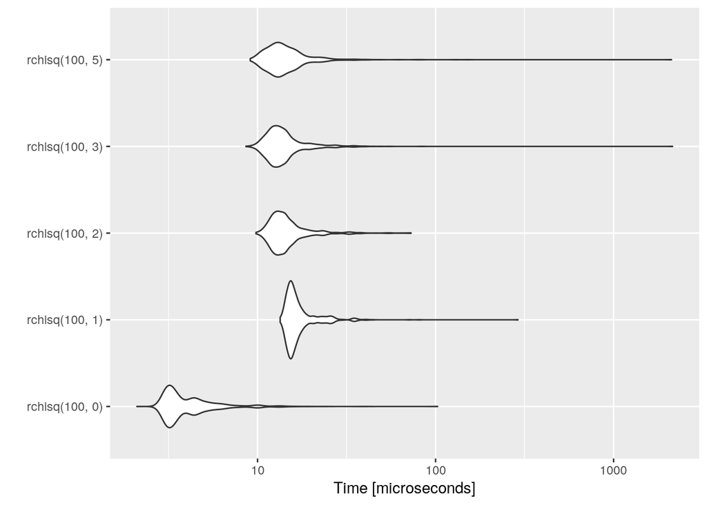

```r
library(magrittr)
library(microbenchmark)
library(ggplot2)

microbenchmark(rchisq(100, 0),
               rchisq(100, 1),
               rchisq(100, 2),
               rchisq(100, 3),
               rchisq(100, 5), times=1000L) %>% autoplot()
```

New package: “bench”

11. Suggestion: use R formats - RDS instead of csv

```r
skip_if_not(curl::has_internet())
```

13. Test with rhub:

```r
check_with_valgrind()
```

14 `Revdepcheck` - reverse dependency (for CRAN packages)

15. [Temporarilly modifying global state using withr](https://github.com/r-lib/withr)
16. [Addin for markdown reports](https://github.com/ThinkR-open/remedy)
17. [Shiny app for adding prefixes to functions](https://github.com/dreamRs/prefixer)

### Keras

https://rstudio.github.io/reticulate/

# DAY 2 (Conference)

### Rust code in R

- https://github.com/r-rust
- https://github.com/r-rust/hellorust

Why to use? - Safer, no pointers, memory leaks - it is memory safe - As safe as C - Native compiler for cross platform - No need of install anything else except R pkg containing compiled Rust code - Has version dependency - Compiled binary does not depend on Rust or Cargo libs

Package gifski

### OO systems in R (S3)

(generic.class/asDate.numer is equivalent to `summary.lm`

```r
# summary <- function(object, …)
useMethod("summary")

sum <- function(..., na.rm = FALSE)
    .Primitive("sum")
```

Dispatch: `summary(lm(y~x))` → `summary.lm(lm(y~x))`ś

Why to use: - Flexible & extensible - Complex types can inherit after simpler type

Example:

```r
dt <- data.table::data.table(mtcars)
print.data.frame(dt)
data.table:::print.data.table(dt)
```

TO check:

- www.github.com/wch/r-source
- Sloop pkg by Hadley

Slides:

- https://github.com/czeildi
- https://github.com/czeildi/erum2018-oop-essentials

### Sentiment Analysis on Social Media and Big Data

- R pkg “iSAX”

### Taking inspiration from proven frontend frameworks to add to Shiny with 6 new packages (appsilon)

- [Shiny.semantic](https://github.com/Appsilon/shiny.semantic) let’s you download semantic UI CSS packages, fully customazible https://cran.r-project.org/web/packages/shiny.semantic/index.html
- [Semantic.dashboard](https://github.com/Appsilon/semantic.dashboard) theme change easy (just put library(semantic.dashboard) instead of library(shiny.dashboard))
- [Shiny.router](https://github.com/Appsilon/shiny.router) makes routing possible with shiny (let’s you pass the args in url)
- [Shiny.router](https://github.com/Appsilon/shiny.router) makes routing possible with shiny (let’s you pass the args in url)

Just for Appsilon clients:

- Shiny.users - access levels for users, authentication handled by shiny done on the app’s side. May be used with google account or ldap
- Shiny.admin - collect stats about app’s activity (what was clicked, how long the session took, etc.)

### Unified Content Analytics Process

- [Formattable package](https://github.com/renkun-ken/formattable) https://cran.r-project.org/web/packages/formattable/vignettes/formattable-data-frame.html
- [rintrojs - interactive tutorials](https://github.com/carlganz/rintrojs)

www.ioki.pl/blog

### Erin LeDell: Scalable Automatic Machine Learning in R

https://github.com/h2oai/h2o-meetups/tree/master/2018_05_15_eRum_AutoML_in_R

### Szilard Pafka: Better than Deep Learning - Gradient Boosting Machines (GBM) in R

- [Package LightGMB](https://github.com/Microsoft/LightGBM/tree/master/R-package)
- szilard/GBM-perf

### Andrie de Vries: Tools for using TensorFlow with R

[tfruns package](https://github.com/rstudio/tfruns)

`ls_run()` → look for hyperparameters:

Parameters can be flagged, e.g. number of runs can be set in list() and then best model can be chosen by ordering by modell accuracy

`Cloudml`

Books: Deeep learning with R Deeo Learning, Googfellow

### Robin Lovelace: Geocomputation for Active transport planning: a case study of cycle network design

https://cran.r-project.org/web/packages/robCompositions/index.html https://github.com/cran/robCompositions

### Way to doing RNA-seq

https://github.com/federicomarini/erum2018

- R pkgs: “pcaExplorer”, “ideal”
- iSEE - interactiveSummarizedExperimentExplorer

# DAY #3 (Conference)

### A practical history of R (where things came from)

- Henrik Bengtsson: A Future for R: Parallel and Distributed Processing in R for Everyone
- https://github.com/HenrikBengtsson/future.batchtools
- Shiny v1.1. Announced and will cointaint promises
- radii.defer: Deferred execution of nested functions

radii.cache

Will be available: https://github.com/tdeenes/radii.defer

### Barbara Borges: Drilldown data discovery with Shiny

https://github.com/bborgesr/erum2018

### Colin Gillespie: Getting the most out of GitHub and friends

R CMD check –as-cran mypkg.tar.gz

Travis Appveyor: https://www.appveyor.com/

Arthur Charpentier: Demographics with Genealogical Data https://3wen.github.io/genealogy/

### Simon Field: Exploiting Spark for high-performance scalable data engineering and data-science on Microsoft Azure

Graph computation on Spark with R: https://www-03.ibm.com/services/learning/ites.wss/zz-en?pageType=badges&id=4fbc7101-62cf-48de-b47d-c3b9e28e4824

### How to choose R package?

- Crantastic: https://www.crantastic.org/
- Metacran: https://www.r-pkg.org/
- Rweekly: https://rweekly.org/

Rmazing code - http://style.tidyverse.org/ - [rOpenSci style guide](https://github.com/ropensci/onboarding/blob/master/packaging_guide.md)

### Robust data pipelines

[Drake R package](https://github.com/ropensci/drake)

Tomaszilagyi.com

### Achim Zeileis: R/exams – A One-for-All Exams Generator

- https://arsnova.uibk.ac.at/mobile/#
- www.r-exams.org

### Tracking changes in data with the lumberjack package

https://github.com/data-cleaning/dcmodify

Lumberjack R pkg to track changes in data

“daff” R package Edwin de Jonge: validatetools - resolve and simplify contradictive or redundant data validation rules https://github.com/data-cleaning/validatetools

### Why to use validate?

To create rule sets Detect conflicting rules

```r
rules <- validator( if (age < 16) income == 0
                     , job %in% c("yes", "no")
                     , if (job == "yes") income > 0)

v <- confront(iris, rules)

quality <- as.data.frame(v)
merge(iris, quality)
```

### Andrea Melloncelli: What software engineers can teach to data scientists: code safety and … with automatic tests

“Shinytest” pkg

Testing upfront (Test Driven approach)

### Wit Jakuczun: Know your R usage workflow to handle reproducibility challenges

www.rsuite.io

### Omayma Said: Fitting Humans Stories in List Columns: Cases From an Online Recruitment Platform

```r
tidyr::nest()
tidyr::unnest()
```

- https://github.com/ropensci/solrium
- http://lucene.apache.org/solr/guide/7_3/solr-tutorial.html
- https://en.wikipedia.org/wiki/Apache_Solr